# Tugas Analisis Multimedia: Audio, Gambar, Video

**Mata Kuliah:** Sistem & Teknologi Multimedia  
**Nama:** Dinda Joycehana  
**NIM:** 122140048

## Deskripsi Tugas

Tugas ini bertujuan untuk memahami representasi dasar data multimedia (audio, gambar, dan video) melalui praktik langsung memuat data, visualisasi, dan ekstraksi informasi fundamental. Anda akan bekerja dengan tiga jenis media berbeda untuk menganalisis karakteristik temporal (audio), spasial (gambar), dan spatio-temporal (video).

Fokus tugas adalah pada pemahaman konsep dasar representasi multimedia dan kemampuan interpretasi hasil visualisasi, **bukan** pada manipulasi atau transformasi lanjutan data multimedia.

## ⚠️ CATATAN PENTING: PRESENTASI ACAK & KEJUJURAN AKADEMIK

**Sebagian mahasiswa akan dipilih secara ACAK untuk presentasi singkat** (5-10 menit) menjelaskan kode dan interpretasi hasil mereka. Jika Anda:

- Tidak mampu menjelaskan kode yang Anda kumpulkan
- Hanya menyalin-tempel tanpa pemahaman
- Bergantung sepenuhnya pada AI tanpa memahami konsep

**Maka nilai tugas Anda akan diberikan 0 (nol).**

Gunakan referensi dan AI sebagai alat bantu pembelajaran, tetapi pastikan Anda memahami setiap baris kode dan dapat menjelaskan logika di baliknya.

```python
# Import Library (Satu-satunya sel kode dalam template ini)
import numpy as np
import matplotlib.pyplot as plt
import librosa
import soundfile as sf
from PIL import Image
import cv2
from IPython.display import Audio, HTML, display
import os

# Set matplotlib untuk menampilkan plot inline
%matplotlib inline

# Tampilkan versi library untuk dokumentasi
print("Library versions:")
print(f"NumPy: {np.__version__}")
print(f"Matplotlib: {plt.matplotlib.__version__}")
print(f"Librosa: {librosa.__version__}")
print(f"OpenCV: {cv2.__version__}")

# Tambahkan import lain jika diperlukan saat mengerjakan tugas
```

```
Library versions:
NumPy: 2.2.6
Matplotlib: 3.10.5
Librosa: 0.11.0
OpenCV: 4.12.0
```

## Petunjuk Umum Pengerjaan

### 📋 Cara Menggunakan Template

- Gunakan notebook ini sebagai kerangka kerja utama
- Tulis penjelasan (markdown) **SEBELUM** menaruh kode agar maksud dan tujuan jelas
- Tambahkan sel kode di tempat yang sudah disediakan (tandai dengan TODO)
- Semua plot/gambar harus diberi judul, label sumbu, dan keterangan singkat

### 📊 Standar Visualisasi

- Setiap plot harus memiliki judul yang deskriptif
- Label sumbu X dan Y harus jelas
- Gunakan colorbar untuk plot yang memerlukan skala warna
- Berikan interpretasi singkat setelah setiap visualisasi

### 📂 Struktur Data yang Direkomendasikan

- Buat folder `data/` di direktori yang sama dengan notebook
- Gunakan nama file yang deskriptif (contoh: `audio_musik_piano.wav`, `gambar_pemandangan_gunung.jpg`)
- Dokumentasikan sumber data jika menggunakan dataset publik

### ⚠️ Larangan

- **Jangan** menaruh seluruh pekerjaan dalam satu sel kode yang sangat panjang
- **Jangan** menempel hasil output tanpa interpretasi atau analisis
- **Jangan** bergantung sepenuhnya pada AI - pahami dan kuasai kode Anda

### 🎯 Persiapan Presentasi Acak

- Pastikan Anda memahami setiap baris kode yang ditulis
- Latih menjelaskan logika dan alur pemikiran Anda
- Siapkan penjelasan untuk setiap visualisasi dan interpretasinya

## Checklist Kelengkapan (Centang ✅ saat selesai)

### 🖼️ Bagian Gambar

- [✅] Tampilkan gambar dengan benar dalam format RGB
- [✅] Tampilkan informasi dasar (dimensi, jumlah kanal, dtype)
- [✅] Tampilkan histogram warna untuk channel R, G, B
- [✅] Berikan analisis hubungan histogram dengan kesan visual gambar

### 📝 Analisis & Dokumentasi

# Pendahuluan

## Apa itu Data Multimedia?

Data multimedia adalah informasi yang dikodekan dalam berbagai format untuk merepresentasikan dunia nyata:

- **Audio (1D)**: Sinyal satu dimensi yang berubah terhadap waktu
  - Contoh: musik, suara, speech
  - Representasi: amplitudo vs waktu
- **Gambar (2D)**: Matriks nilai intensitas dalam ruang dua dimensi
  - Contoh: foto, ilustrasi, grafik
  - Representasi: intensitas pixel pada koordinat (x,y)
- **Video (2D + Waktu)**: Rangkaian frame (gambar) yang ditampilkan berurutan
  - Contoh: film, rekaman, animasi
  - Representasi: frame berubah terhadap waktu dengan frame rate tertentu

## Tujuan Tugas

Memahami representasi dasar dan teknik visualisasi fundamental untuk setiap jenis media multimedia, termasuk:

- Cara memuat dan membaca file multimedia
- Ekstraksi informasi metadata yang penting
- Visualisasi yang informatif dan mudah dipahami
- Interpretasi hasil analisis secara kontekstual

## Cara Kerja

1. Isi setiap bagian sesuai instruksi yang diberikan
2. Tambahkan sel kode di tempat yang ditandai dengan "TODO"
3. Berikan interpretasi dan analisis setelah setiap visualisasi
4. Pastikan semua plot memiliki judul, label, dan keterangan yang jelas

# Bagian A — Audio

### A1. Deskripsi Data

**TODO:** Jelaskan audio yang akan Anda analisis:

- Jenis audio: Musik Jazz Instrumental
- Sumber: Youtube [[Link Youtube](https://youtu.be/TOxUuUlUIpw?si=prBQX1wuS1ShSuOu)]
- Format file: MP3
- Alasan pemilihan: berisi beragam bunyi alat musik yang memiliki frekuensi berbeda-beda dalam audio tersebut, sehingga cocok untuk melihat gelombang, spektrum, dan testing audio untuk melihat informasi dari audio.

**Path file:** `data/jazz_instrument.mp3`

### A2. TODO: Muat & Metadata

**Instruksi:** Tulis kode untuk memuat file audio dan menampilkan metadata dasar:

- Sample rate (Hz)
- Durasi (detik)
- Jumlah kanal (mono/stereo)
- Jumlah total sampel

**Catatan:** Jika file MP3 bermasalah saat loading, gunakan format WAV sebagai alternatif.

```python
### A2. Todo : Muat &  Metadata
# Muat file audio dan tampilkan metadata dasar
audio_path = 'data/jazz_instrument.mp3'  # Ganti dengan path file audio Anda

# Membaca file audio (sf.read bisa membaca mp3 jika backend mendukung, jika error gunakan wav)
data, samplerate = sf.read(audio_path)
duration = len(data) / samplerate

# Jumlah kanal: jika data 1D = mono, jika 2D = stereo/multi
if data.ndim == 1:
    channels = 1
    channel_type = "Mono"
else:
    channels = data.shape[1]
    channel_type = "Stereo" if channels == 2 else f"{channels} channels"

print("Metadata Audio")
print("=" * 40)
print(f"Sample rate: {samplerate} Hz")
print(f"Durasi: {duration:.2f} detik")
print(f"Jumlah kanal: {channels} ({channel_type})")
print(f"Jumlah total sampel: {data.shape[0]:,}") # Total sampel = durasi * sample rate
print()
print("Statistik Amplitudo")
print("=" * 40)
print(f"Nilai minimum: {np.min(data):.4f}")
print(f"Nilai maksimum: {np.max(data):.4f}")
print(f"Nilai rata-rata: {np.mean(data):.4f}")
print(f"Standar deviasi: {np.std(data):.4f}")
```

```
Metadata Audio
========================================
Sample rate: 48000 Hz
Durasi: 271.56 detik
Jumlah kanal: 2 (Stereo)
Jumlah total sampel: 13,034,880

Statistik Amplitudo
========================================
Nilai minimum: -1.0821
Nilai maksimum: 1.1279
Nilai rata-rata: -0.0000
Standar deviasi: 0.2160
```

### A3. TODO: Waveform

**Instruksi:** Plot waveform audio dengan:

- Sumbu X: waktu (detik)
- Sumbu Y: amplitudo
- Judul dan label sumbu yang jelas

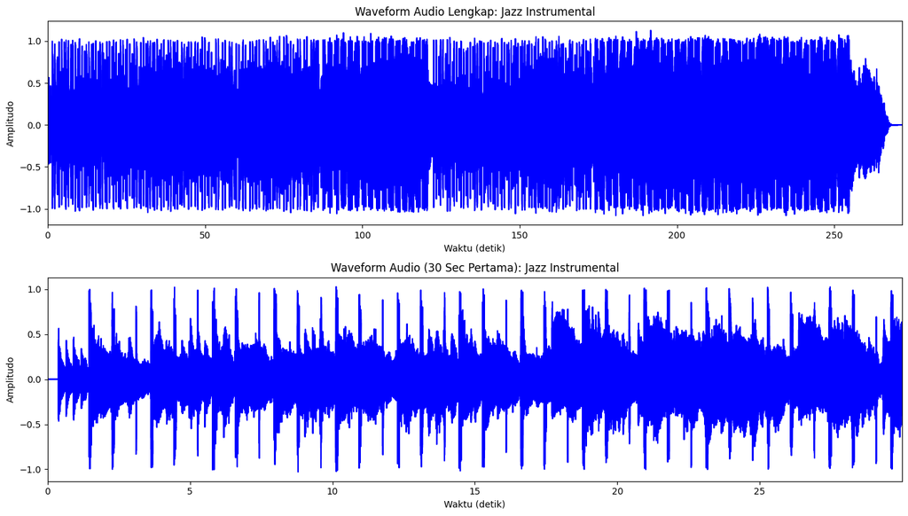

```python
#plot waveform audio
fig, (ax1, ax2) = plt.subplots(2, 1, figsize=(14, 8))

# Plot 1: waveform audio Lengkap
times = np.arange(len(data)) / samplerate
ax1.plot(times, data, color='blue')
ax1.set_title("Waveform Audio Lengkap: Jazz Instrumental")
ax1.set_xlabel("Waktu (detik)")
ax1.set_ylabel("Amplitudo")
ax1.set_xlim([0, times[-1]])

# Plot 2: waveform audio 30-second pertama
max_duration = 30  # detik
max_samples = int(samplerate * max_duration)
data_30sec = data[:max_samples]
times_30sec = np.arange(len(data_30sec)) / samplerate

ax2.plot(times_30sec, data_30sec, color='blue')
ax2.set_title("Waveform Audio (30 Sec Pertama): Jazz Instrumental")
ax2.set_xlabel("Waktu (detik)")
ax2.set_ylabel("Amplitudo")
ax2.set_xlim([0, min(max_duration, times_30sec[-1])])

plt.tight_layout()
plt.show()
```

**Analisis yang diperlukan:** Jelaskan apa yang Anda lihat dari waveform (pola amplitudo, bagian keras/pelan, dll.)

**Jawaban Analisis:** Berdasarkan gambar waveform diatas, menunjukkan bentuk amplitudo gelombang hampir rata dan padat, berkisar -+(0.5-1). Akan tetapi pada detik direntang 120-130 dan mendekati akhir audio, gelombang tampak mengecil. Mungkin part yang gelombangnya kecil ini berisi jeda lagu, transisi, ending lagu, yang berupa alunan musik bervolume rendah. Di rentang 180-250 detik terlihat gelombang sedikit lebih padat dengan amplitudo tinggi, kemungkinan disini adalah bagian-bagian yang beritme cepat dengan volume tinggi.

Jika dilihat pada gambar yang 30 detik pertawa, terlihat pola amplitudo dari rendah ke besar secara signifikan. Kemungkinan amplitudo yang tinggi tersebut merupakan suara dari bass.

### A4. TODO: Spectrogram log-dB

**Instruksi:** Hitung STFT dan tampilkan spectrogram dalam skala log-dB:

- Gunakan parameter standar (n_fft=1024, hop_length=256)
- Tampilkan dengan colorbar
- Label sumbu: waktu (detik) dan frekuensi (Hz)

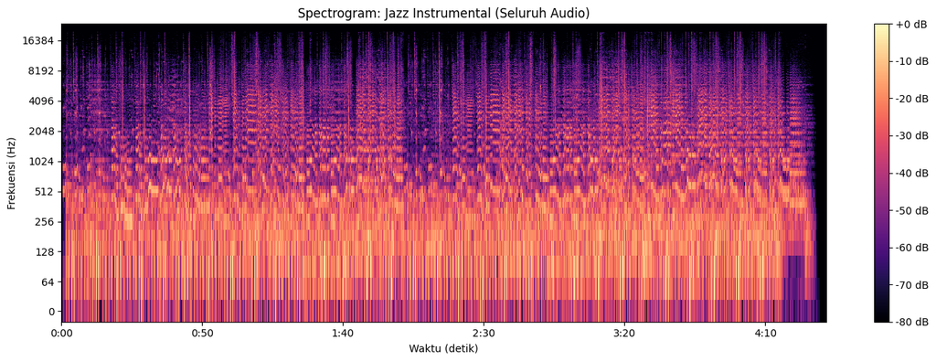

```python
### A4. Todo: Spectrogram log-dB
n_fft = 1024  # Panjang jendela FFT
hop_length = 256  # Jarak antar jendela

# Karena audio stereo, konversi ke mono dengan merata-rata kedua channel
y = data if data.ndim == 1 else np.mean(data, axis=1)

spectrogram = librosa.stft(y, n_fft=n_fft, hop_length=hop_length)
spectrogram_db = librosa.amplitude_to_db(np.abs(spectrogram), ref=np.max)

plt.figure(figsize=(14, 5))
librosa.display.specshow(spectrogram_db, y_axis='log', x_axis='time', sr=samplerate, hop_length=hop_length)
plt.colorbar(format='%+2.0f dB')
plt.title("Spectrogram: Jazz Instrumental (Seluruh Audio)")
plt.xlabel("Waktu (detik)")
plt.ylabel("Frekuensi (Hz)")
plt.tight_layout()
plt.show()
```

**Analisis yang diperlukan:** Jelaskan perbedaan informasi yang didapat dari spectrogram dibanding waveform.

Berdasarkan gambar spectogram diatas, audio didominasi oleh suara berfrekuensi rendah direntang 50-2000Hz , dapat dilihat kepadatan warna kuning terang pada gambar. Spectogram ini menunjukkan bahwa audio kemungkinan diisi oleh suara alat musik seperti bass atau drum. Namun suara berfrekuensi tinggi juga cukup padat memenuhi audio. Kemungkinan ini merupakan suara dari instrumen lainnya pada musik jazz, seperti piano, Saxo,gitar, ataupun gemerincing (tipis).

Pada suara berferekunsi tinggi, masih sering bercampur dengan suara berfrekuensi rendah. Kemungkinan karena musik jazz memainkan beragam musik di waktu bersamaan, sehingga warnanya bercampur terang dan gelap.

### A5. TODO: MFCC

**Instruksi:** Hitung dan tampilkan minimal 13 koefisien MFCC sebagai heatmap:

- Sumbu X: waktu (frame)
- Sumbu Y: koefisien MFCC (1-13)
- Gunakan colorbar dan judul yang jelas

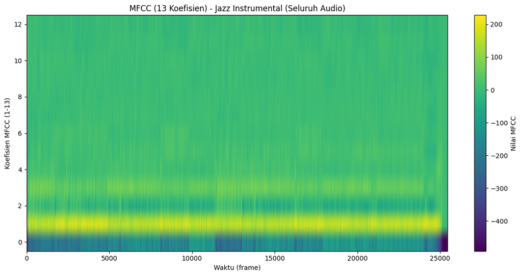

```python
### A5. Todo: MFCC
# Hitung dan tampilkan minimal 13 koefisien MFCC sebagai heatmap untuk seluruh audio

# Karena audio stereo, konversi ke mono dengan merata-rata kedua channel
y = data if data.ndim == 1 else np.mean(data, axis=1)

mfccs = librosa.feature.mfcc(y=y.astype(float), sr=samplerate, n_mfcc=13)

plt.figure(figsize=(12, 6))
im = plt.imshow(mfccs, aspect='auto', origin='lower', cmap='viridis')
plt.title("MFCC (13 Koefisien) - Jazz Instrumental (Seluruh Audio)")
plt.xlabel("Waktu (frame)")
plt.ylabel("Koefisien MFCC (1-13)")
plt.colorbar(im, label="Nilai MFCC")
plt.tight_layout()
plt.show()
```

### A6. Analisis Ringkas (Wajib)

**Jawab pertanyaan berikut:**

# Bagian B — Gambar

### B1. Deskripsi Data

**TODO:** Jelaskan gambar yang akan Anda analisis:

- Jenis gambar: Foto di posko KKN
- Sumber: Foto Pribadi
- Format file: JPG
- Alasan pemilihan: Cukup beragam warna, menarik untuk di tes dan analisis.

**Path file:** `data/foto_KKN.jpg` (isi nama file Anda nanti di kode)

### B2. TODO: Baca & Tampilkan (RGB)

**Instruksi:** Baca gambar dan tampilkan dengan benar dalam format RGB:

- Pastikan konversi warna benar (ingat perbedaan BGR vs RGB di OpenCV)
- Berikan judul yang deskriptif
- Hilangkan axis untuk tampilan yang bersih

[figure not shown]

```python
### B2. Todo: Muat & Metadata Gambar
# Baca gambar dan tampilkan dalam format RGB

image_path = 'data/foto_KKN.JPG'

# Membaca gambar dengan OpenCV (hasilnya BGR)
image_bgr = cv2.imread(image_path)
image_rgb = cv2.cvtColor(image_bgr, cv2.COLOR_BGR2RGB)

plt.figure(figsize=(8, 6))
plt.imshow(image_rgb)
plt.title("Foto di Posko KKN (Format RGB)")
plt.axis('off')  # Hilangkan axis
plt.show()
```

**Analisis yang diperlukan:** Jelaskan gambar secara ringkas (objek dominan, kondisi pencahayaan, komposisi warna).

**Jawaban Analisis:** Gambar yang dimuat adalah foto di depan posko KKN yang ambil di outdoor pada siang hari. Sehingga pencahayaannya terang. Objek di domisasi oleh rumah dan anggota kkn dengan rumput dibawah serta langit yang seperti putih karena cerah terkena cahaya matahari. Komposisi warna beragam dari cerah hingga gelap

### B3. TODO: Informasi Dasar

**Instruksi:** Tampilkan informasi metadata gambar:

- Dimensi (Height × Width)
- Jumlah kanal
- Tipe data (dtype)
- Mode warna (jika relevan)
- Ukuran file dalam memori

```python
### B3. Todo: Informasi Dasar Gambar
# Tampilkan metadata gambar

image_path = 'data/foto_KKN.JPG'

# Membaca gambar dengan OpenCV
image_bgr = cv2.imread(image_path)
height, width, channels = image_bgr.shape
dtype = image_bgr.dtype
mode = "RGB" if channels == 3 else "Grayscale"
size_bytes = image_bgr.nbytes  # Ukuran file dalam memori (byte)

print("Metadata Gambar")
print("=" * 40)
print(f"Dimensi: {height} x {width} (Height x Width)")
print(f"Jumlah kanal: {channels}")
print(f"Tipe data: {dtype}")
print(f"Mode warna: {mode}")
print(f"Ukuran file dalam memori: {size_bytes:,} bytes")
```

```
Metadata Gambar
========================================
Dimensi: 3000 x 4496 (Height x Width)
Jumlah kanal: 3
Tipe data: uint8
Mode warna: RGB
Ukuran file dalam memori: 40,464,000 bytes
```

**Analisis yang diperlukan:** Jelaskan mengapa informasi ini penting untuk tahap preprocessing atau analisis lanjutan.

**Jawaban Analisis**

Informasi ini penting dalam tahap prepocessing atau analisis lanjut adalah untuk mengetahui tindak lanjut dari si image ini. Contohnya seperti menangani perbedaan karnal warna (misal dari greyscale ke RGB), menjaga konsistensi data, mengatasi deteksi data corrupt, ataupun mengubah/merotasi image.

### B4. TODO: Histogram Warna

**Instruksi:** Tampilkan histogram distribusi intensitas untuk channel R, G, B:

- Range: 0-255
- Plot terpisah atau overlay dengan warna sesuai channel
- Label sumbu: intensitas pixel dan frekuensi
- Legend yang jelas

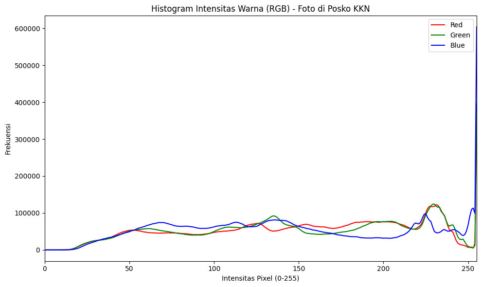

```python
### B4. Todo: Histogram Warna
# Histogram distribusi intensitas untuk channel R, G, B

image_path = 'data/foto_KKN.JPG'

# Membaca gambar dan konversi ke RGB
image_bgr = cv2.imread(image_path)
image_rgb = cv2.cvtColor(image_bgr, cv2.COLOR_BGR2RGB)

plt.figure(figsize=(10, 6))
channels = ['Red', 'Green', 'Blue']
colors = ['r', 'g', 'b']

for i, color in enumerate(colors):
    hist = cv2.calcHist([image_rgb], [i], None, [256], [0, 256])
    plt.plot(hist, color=color, label=channels[i])
    plt.xlim([0, 255])

plt.title("Histogram Intensitas Warna (RGB) - Foto di Posko KKN")
plt.xlabel("Intensitas Pixel (0-255)")
plt.ylabel("Frekuensi")
plt.legend()
plt.tight_layout()
plt.show()
```

**Analisis yang diperlukan:** Analisis: channel mana yang dominan? Bagaimana kontras gambar? Seperti apa sebaran intensitasnya?

**Jawaban Analisis:**

- Di rentang pixel 0-50, setiap pixel memiliki RGB yang hampir sama rata frekuensinya, kemungkinan ini menandakan gambar berwarna gelap.
- Selanjutnya dari 50-150, channel biru lebih mendominasi, kemungkinan dalam rentang ini berisi warna-warna yang tidak terlalu terang maupun terlalu gelap(sedang), mungkin seperti banner atau warna baju. Walau ada sedikit perubahan di rentang 130-150 yaitu hijau mendominasi, bisa saja karena warna rumput.
- Kemudian di rentang 150-250 di dominasi warna merah dan hijau, kemungkinan ini adalah warna-warna coklat/sedikit pucat. Kemungkinan ini adalah warna-warna yang cukup terang, seperti warna dinding rumah ataupun vest kkn. Dan terakhir ada lonjakan tinggi dari 250 keatas terhadap warna biru, merah, dan hijau, ini menandakan ada warna yang sangat terang, kemungkinan adalah langit yang sudah hampir putih.

### B5. Analisis Ringkas (Wajib)

**Jawab pertanyaan berikut:**

**Relasi histogram dengan kesan visual:** Apa hubungan antara pola histogram yang Anda lihat dengan kesan visual gambar (terang/gelap, warna dominan, kontras)?

**Jawaban Anda:** frekuensi RGB pada rentang intensitas pixel akan memberi informasi warna-warna yang mendominasi setiap pixel pada gambar.

Dengan begitu, kita bisa menilai bahwa foto tersebut lebih terkesan dingin/kebiruan dan cerah, karena penyebaran frekuensi warna RGB tinggi berada pada intensitas menengah-tinggi yaitu 50-255.

Sedangkan pada intensitas pixel 0-50, tidak begitu mendominasi atau nilai frekuensinya masih rendah. Artinya hanya sebagian kecil dari gambar yang memiliki warna gelap. Jika banyak pixel pada gambar yang berwarna gelap, seharusnya frekuensi rgb pada intensitas 0-50 bernilai tinggi.

# Bagian C — Video

### C1. Deskripsi Data

**TODO:** Jelaskan video yang akan Anda analisis:

- Jenis video: Perkenalan Diri
- Sumber: Rekaman Pribadi
- Durasi target: 10 Detik
- Alasan pemilihan: Biar simple, ga perlu download

### C2. TODO: Baca & Metadata

**Instruksi:** Baca video dengan OpenCV dan tampilkan metadata:

- Resolusi (Width × Height)
- Frame rate (fps)
- Jumlah total frame
- Durasi (detik)
- Klasifikasi resolusi (HD, Full HD, 4K, dll.)

```python
### C2. Todo: Baca & Metadata Video
# Baca video dan tampilkan metadata

video_path = 'data/Video_perkenalan_dinda.mp4'

cap = cv2.VideoCapture(video_path)
width = int(cap.get(cv2.CAP_PROP_FRAME_WIDTH))
height = int(cap.get(cv2.CAP_PROP_FRAME_HEIGHT))
fps = cap.get(cv2.CAP_PROP_FPS)
frame_count = int(cap.get(cv2.CAP_PROP_FRAME_COUNT))
duration = frame_count / fps if fps > 0 else 0

# Klasifikasi resolusi
if width >= 3840 and height >= 2160:
    res_class = "4K"
elif width >= 1920 and height >= 1080:
    res_class = "Full HD"
elif width >= 1280 and height >= 720:
    res_class = "HD"
else:
    res_class = "SD/Low"

print("Metadata Video")
print("=" * 40)
print(f"Resolusi: {width} x {height} (Width x Height)")
print(f"Frame rate: {fps:.2f} fps")
print(f"Jumlah total frame: {frame_count}")
print(f"Durasi: {duration:.2f} detik")
print(f"Klasifikasi resolusi: {res_class}")

cap.release()
```

```
Metadata Video
========================================
Resolusi: 1280 x 720 (Width x Height)
Frame rate: 29.86 fps
Jumlah total frame: 313
Durasi: 10.48 detik
Klasifikasi resolusi: HD
```

**Analisis yang diperlukan:** Jelaskan pentingnya parameter-parameter tersebut untuk analisis video atau aplikasi tertentu.

**Jawaban Analisis:**

Hampir sama dengan keperluan metadata image, yaitu agar lebih mengetahui tindakan apa yang dilakukan untuk sebelum memproses/mengolah data video tersebut. Sehingga informasi pada video tidak hilang dan meningkatkan keakuratan dalam analisis.

### C3. TODO: Tampilkan 3 Frame (Awal–Tengah–Akhir)

**Instruksi:** Ambil dan tampilkan 3 frame representatif:

- Frame pertama (index 0)
- Frame tengah (index ~total_frame/2)
- Frame terakhir (index total_frame-1)
- **Konversi BGR→RGB** sebelum ditampilkan
- Subplot dengan judul frame dan timestamp

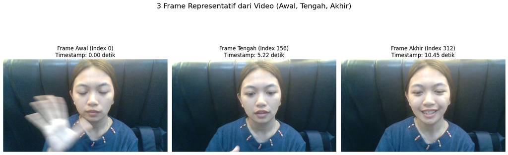

```python
### C3. Todo: Tampilkan 3 Frame (Awal–Tengah–Akhir)
# Ambil dan tampilkan 3 frame representatif dari video (awal, tengah, akhir)
video_path = 'data/Video_perkenalan_dinda.mp4'

cap = cv2.VideoCapture(video_path)
frame_count = int(cap.get(cv2.CAP_PROP_FRAME_COUNT))
fps = cap.get(cv2.CAP_PROP_FPS)

# Indeks frame yang diambil
indices = [0, frame_count // 2, frame_count - 1]
frames = []
timestamps = []

for idx in indices:
    cap.set(cv2.CAP_PROP_POS_FRAMES, idx)
    ret, frame = cap.read()
    if ret:
        # Konversi BGR ke RGB
        frame_rgb = cv2.cvtColor(frame, cv2.COLOR_BGR2RGB)
        frames.append(frame_rgb)
        # Hitung timestamp (detik)
        timestamp = idx / fps if fps > 0 else 0
        timestamps.append(timestamp)
    else:
        frames.append(None)
        timestamps.append(None)

cap.release()

# Tampilkan frame dengan subplot
plt.figure(figsize=(16, 6))
titles = [
    f"Frame Awal (Index 0)\nTimestamp: {timestamps[0]:.2f} detik",
    f"Frame Tengah (Index {indices[1]})\nTimestamp: {timestamps[1]:.2f} detik",
    f"Frame Akhir (Index {indices[2]})\nTimestamp: {timestamps[2]:.2f} detik"
]

for i, (frame, title) in enumerate(zip(frames, titles)):
    plt.subplot(1, 3, i + 1)
    if frame is not None:
        plt.imshow(frame)
        plt.title(title)
        plt.axis('off')
    else:
        plt.text(0.5, 0.5, "Frame tidak tersedia", ha='center', va='center')
        plt.axis('off')

plt.suptitle("3 Frame Representatif dari Video (Awal, Tengah, Akhir)", fontsize=16)
plt.tight_layout(rect=[0, 0, 1, 0.95])
plt.show()
```

**Analisis yang diperlukan:** Deskripsikan perbedaan visual antar frame dan apa yang dapat dipelajari dari sampel frame ini.

**Jawaban Analisis:**

- Pada frame 1 ada bagian gambar yang blur/bersambung, yaitu bentuk lambaian tangan (gerakan cepat).
- Pada frame 2 juga masih terlihat sedikit bagian blur pada jari jempol bawah. Dan bagian atas gambar tampak lebih cerah akibat cahaya lampu. Berefek juga pada tingkat kecerahan gambar yaitu jadi sedikit lebih cerah
- pada frame 3 frame lebih stabil, tidak ada terlihat bagian blur.

Kemungkinan penyebab blur pada gambar dipengaruhi oleh fps 30, sehingga gerakannya lebih patah-patah karena frame nya hanya mengcapture 30 frame per second. Semakin banyak fps, hasil video akan semakin mulus, karena frame yang dicapture lebih banyak, sehingga pergerakannya lebih detail.

### C4. Analisis Ringkas (Wajib)

**Jawab pertanyaan berikut:**

# Perbandingan & Kesimpulan

## Perbandingan Representasi Media

**TODO:** Bandingkan secara ringkas representasi dan visualisasi ketiga media:

### Audio (1D - Temporal)

- Representasi: Sinyal 1D dengan melihat amplitudo dan frekuensi pada waktu
- Visualisasi utama: Waveform, Spectogram, dan MFCC
- Informasi yang diperoleh: Pola gelombang amplitudo, penyebaran frekuensi audio, ritme, durasi.

### Gambar (2D - Spasial)

- Representasi: Matriks 2D
- Visualisasi utama: Tampilan gambar, histogram frekuensi warna pada intensitas pixel.
- Informasi yang diperoleh: Pola frekuensi pada intensitas warna disetiap pixel, pengaruh warna dalam memberi kesan gelap/terang pada gambar

### Video (2D + Waktu - Spatio-temporal)

- Representasi: Urutan frame beserta audio
- Visualisasi utama: rangkaian frame sample
- Informasi yang diperoleh: pengaruh resolusi dan fps dalam menangkap interaksi objek/perubahan gerak.

## Refleksi Pembelajaran

### 3 Poin yang Saya Pelajari:

1. Waveform lebih menginformasikan terkait volume atau keras/pelannya suatu suara. Sedangkan spectogram menginformasikan terkait frekuensi dari suara itu sendiri.
2. MFCC mirip dengan spectogram, hanya bentuk ringkasnya dan dipadatkan menyesuaikan kemampuan pendengaran manusia.
3. Resolusi dan FPS sangat memengaruhi kualitas pengambilan video. Semakin besar resolusi dan fps nya, maka kualitas video semakin baik, lebih jernih dan lebih detail.

### 2 Hal yang Masih Membingungkan/Ingin Diperdalam:

1. Terkait mel dan MFCC
2. Kenapa bisa ada blur pada frame saat gerakan cepat?

## Sumber Data & Referensi

**TODO:** Cantumkan semua sumber data dan referensi yang digunakan:

- **Audio:** [Link Youtube Tautan](https://youtu.be/TOxUuUlUIpw?si=prBQX1wuS1ShSuOu)
- **Gambar:** Foto Pribadi Saat KKN
- **Video:** Video Rekaman Pribadi dari Laptop
- **Referensi teknis:** [LINK GPT](https://chatgpt.com/share/68c836d3-b2cc-8008-94ca-d8eefe7c2ef5)

[figure not shown]

# Rubrik Penilaian

## Distribusi Bobot Penilaian

| **Aspek Penilaian** | **Bobot** | **Deskripsi** |
| --- | --- | --- |
| **Kelengkapan** | **35%** | Semua langkah inti dikerjakan sesuai checklist |
| **Kualitas Visualisasi** | **20%** | Judul, label sumbu, colorbar, legend, keterbacaan plot |
| **Analisis & Interpretasi** | **30%** | Kemampuan interpretasi hasil, bukan sekadar output mentah |
| **Kerapihan & Struktur** | **10%** | Markdown jelas, kode modular, dokumentasi baik |
| **Orisinalitas & Penguasaan** | **5%** | Pemahaman saat presentasi acak |

## Detail Kriteria Penilaian

### 🏆 Kelengkapan (35%)

- ✅ Semua 4 visualisasi audio (metadata, waveform, spectrogram, MFCC)
- ✅ Semua 3 visualisasi gambar (display RGB, metadata, histogram)
- ✅ Semua 2 visualisasi video (metadata, frame extraction)
- ✅ Analisis ringkas untuk setiap bagian

### 📊 Kualitas Visualisasi (20%)

- Plot memiliki judul yang informatif dan deskriptif
- Label sumbu X dan Y jelas dan sesuai
- Colorbar/legend tersedia jika diperlukan
- Ukuran plot proporsional dan mudah dibaca

### 🧠 Analisis & Interpretasi (30%)

- Interpretasi menunjukkan pemahaman konsep
- Analisis kontekstual, bukan sekadar deskripsi output
- Mampu menghubungkan hasil dengan teori
- Refleksi pembelajaran yang thoughtful

### 📝 Kerapihan & Struktur (10%)

- Markdown terstruktur dengan heading yang konsisten
- Kode bersih, terkompartemen, dan mudah dibaca
- Dokumentasi yang memadai
- Flow logical dari satu bagian ke bagian lain

### 🎯 Orisinalitas & Penguasaan (5%)

- **PENTING:** Jika saat presentasi acak Anda tidak mampu menjelaskan kode yang Anda tulis atau menunjukkan ketergantungan buta pada AI/copy-paste, **nilai tugas akan dianggap 0**.
- Kemampuan menjelaskan logika dan alur pemikiran
- Pemahaman konsep di balik implementasi kode

## Proporsi Penilaian Total

- Proporsi penilaian hanya 80%, 20% lagi akan didasarkan pada kecepatan pengumpulan tugas
- Sehingga: 0.8 * penilaian dosen + nilai waktu pengumpulan

# Aturan Kejujuran Akademik

## 📖 Penggunaan Referensi & AI yang Diperbolehkan

Anda **BOLEH** menggunakan:

- ✅ Dokumentasi resmi library (NumPy, Matplotlib, Librosa, OpenCV)
- ✅ Tutorial dan contoh kode dari sumber terpercaya
- ✅ AI tools (ChatGPT, GitHub Copilot, dll.) sebagai **alat bantu pembelajaran**
- ✅ Diskusi dengan teman untuk pemahaman konsep

## ⚠️ Syarat & Batasan WAJIB

Namun Anda **HARUS**:

- 🧠 **Memahami setiap baris kode** yang Anda masukkan ke notebook
- 📝 **Menulis interpretasi dengan kata-kata sendiri**, bukan hasil copy-paste
- 📚 **Mencantumkan sumber data dan referensi** yang digunakan, termasuk transkrip percakapan dengan AI dalam link atau teks
- 🎯 **Mampu menjelaskan logika dan alur pemikiran** saat presentasi acak

## ❌ Pelanggaran yang Berakibat Nilai 0

- **Plagiarisme atau penyalinan buta** dari sumber manapun
- **Copy-paste kode tanpa pemahaman** dan tidak dapat menjelaskan
- **Menggunakan AI untuk mengerjakan seluruh tugas** tanpa pembelajaran personal
- **Tidak dapat menjawab pertanyaan dasar** tentang kode yang dikumpulkan
- **Menyalin pekerjaan teman** atau bekerjasama dalam pengerjaan individual

## 🎯 Persiapan Presentasi Acak

**Kemungkinan pertanyaan yang akan ditanyakan:**

- "Jelaskan mengapa Anda menggunakan parameter ini di STFT?"
- "Apa arti dari pola yang terlihat di MFCC?"
- "Mengapa perlu konversi BGR ke RGB?"
- "Interpretasikan hasil histogram yang Anda buat"
- "Bagaimana cara kerja spectrogram?"

**Tips sukses:**

- Pahami konsep dasar setiap teknik yang digunakan
- Latih menjelaskan dengan bahasa sederhana
- Siapkan justifikasi untuk setiap pilihan parameter
- Kuasai interpretasi setiap visualisasi yang dibuat

# Panduan Pengumpulan

## 📁 Berkas yang Harus Dikumpulkan

### Wajib:

1. **Notebook Jupyter** (.ipynb) dengan nama: `NIM_Nama_TugasMultimedia.ipynb`
   - Contoh: `123456789_JohnDoe_TugasMultimedia.ipynb`
2. **PDF hasil render dari notebook**

## 📅 Informasi Pengumpulan

## ✅ Checklist Sebelum Submit

- [✅] Semua cell sudah dijalankan dan menampilkan output
- [✅] Nama file sesuai format: `NIM_Worksheet2.ipynb` dan `NIM_Worksheet2.pdf`
- [✅] Semua TODO sudah diisi dengan lengkap
- [✅] Analisis dan interpretasi sudah ditulis untuk setiap bagian
- [✅] Sumber data dan referensi sudah dicantumkan

### Export ke PDF:

- File → Save and Export Notebook As → HTML
- Buka HTML di browser -> Save as PDF